# Triagem inteligente de tickets — G4 Educação

O que os dados dizem sobre o fluxo de atendimento, o que um classificador resolve — e o que deve continuar nas mãos de pessoas.

33%

dos tickets nunca recebem 1ª resposta (2.819 de 8.469)

67%

do fluxo parado — esperando operação ou cliente

R$ 15 mil

custo único para limpar o backlog (~700 h, 0,4 FTE-ano)

87,8%

acurácia do classificador de tópicos no holdout

role para ler o diagnóstico ↓

1 · O diagnóstico

## O gargalo é o começo, não a execução — e a nota de satisfação é sorteio

**Um terço dos clientes nunca recebe a primeira resposta e 67% do fluxo está parado** — não por canal, prioridade ou tipo de ticket, mas por processo. Nenhum fator explica o tempo de resolução porque os relógios do sistema estão quebrados; e as notas de satisfação se comportam como um dado de 5 faces, não como opinião de cliente.

### 67% do fluxo parado

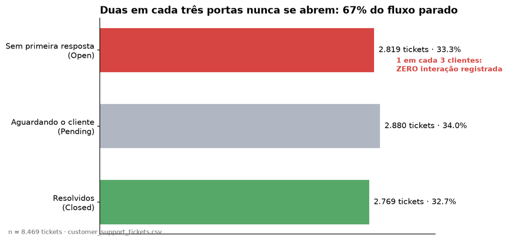

2.819 tickets (33,3%) sem nenhuma primeira resposta · 2.880 (34,0%) aguardando o cliente · só 32,7% resolvidos — e, quando o fluxo anda, em horas. O gargalo é o começo do fluxo, não a execução.

### A nota é um dado de 5 faces

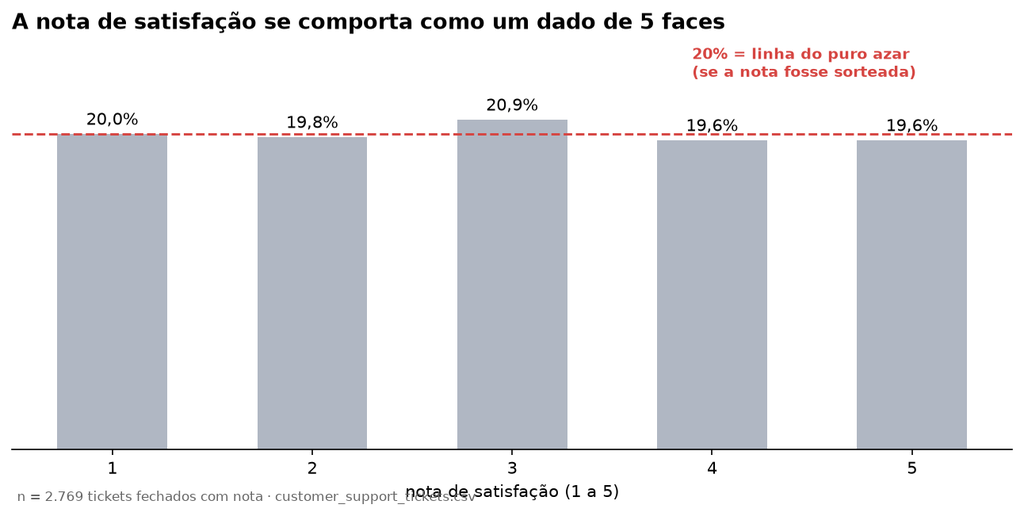

Das 2.769 notas existentes (só tickets fechados, média 2,99), cada nota aparece com ~20% de frequência — padrão de sorteio, não de opinião. Tempo, canal e tipo não têm efeito; todos os atributos juntos explicam 2% da variância.

### O desperdício é tempo de cliente

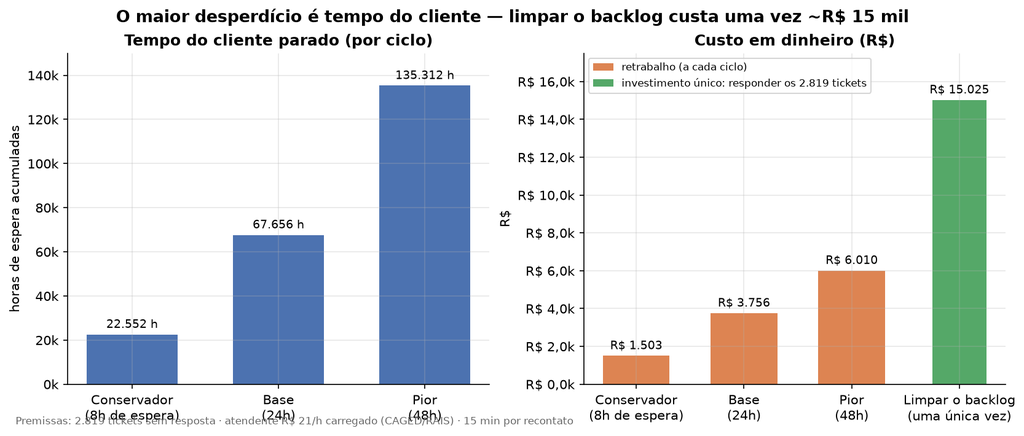

O sistema não guarda a data de criação do ticket — a espera é cenário, com premissas declaradas (R$ 21/h carregado, CAGED/RAIS; 15 min por recontato). O desperdício principal é tempo de cliente parado, não folha.

2.819

tickets sem 1ª resposta — único grupo 100% nas mãos da operação

49,3%

dos "tempos" registrados são cronologicamente impossíveis — relógios quebrados

~20%

em cada nota de CSAT — não guie nenhum investimento por ela

R$ 3,8 mil

de retrabalho por ciclo no cenário base (24h de espera, 25% retornam)

Fonte: `analysis/relatorio_fluxo_atendimento.md` — EDA de `customer_support_tickets.csv` (8.469 tickets, 17 colunas; testes Kruskal-Wallis, Spearman, Bonferroni).

2 · A solução — classificador

## Do chute ao modelo: 28,5% → 87,8% de acerto em 8 tópicos

Três métodos testados sobre 47.837 tickets (holdout 80/20, 8 classes de tópico). A escada de baselines define o piso; o fine-tuning define o teto prático.

Classe majoritária  
baseline

28,5%

Zero-shot  
piso do transformer

~32%

TF-IDF (word 1–2)  
+ LogReg

86,8%

DistilBERT fine-tuned  
escolhido

87,8%

Acurácia no holdout de 9.568 tickets · DistilBERT: macro-F1 87,5%, 3 épocas, max_length 192 · TF-IDF+LogReg: 86,78% · zero-shot sem fine-tuning como piso de referência.

### Onde o modelo erra

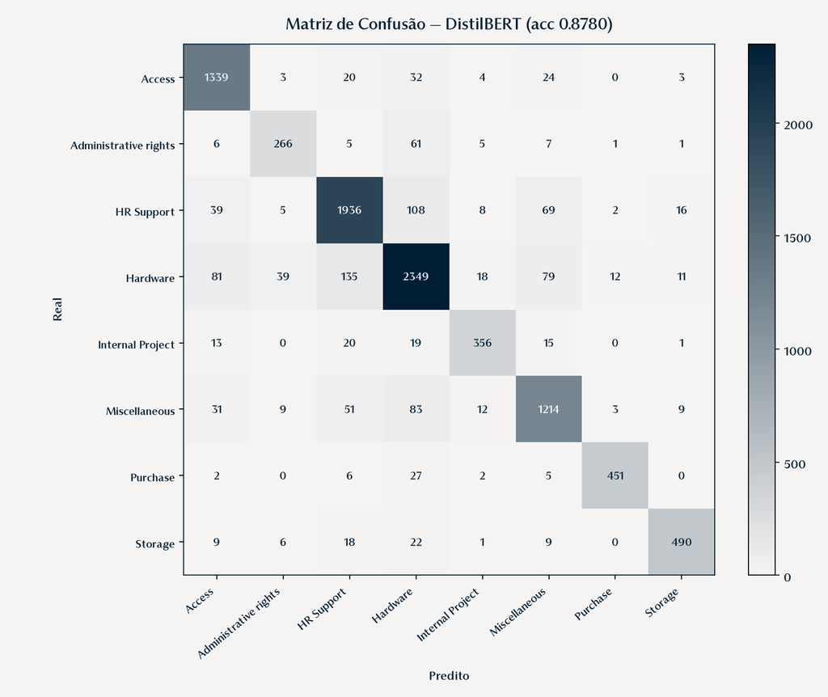

### As classes mais difíceis

| Classe | Precisão | Revocação | F1 | n |
| --- | --- | --- | --- | --- |
| Administrative rights | 81,1% | 75,6% | 78,2% | 352 |
| Miscellaneous | 85,4% | 86,0% | 85,7% | 1.412 |
| Internal Project | 87,7% | 84,0% | 85,8% | 424 |
| Hardware | 87,0% | 86,2% | 86,6% | 2.724 |

A pior classe é **Administrative rights** (F1 0,78 — permissions, resets de conta): baixa revocação e consequência alta quando errado. Por isso a regra operacional:

### Administrative rights → sempre humano

Nenhum ticket desta classe segue para automação, mesmo quando o modelo acerta.

Fontes: `solution/artifacts/step1_results.json` · `solution/artifacts/transformer/step2_results.json` · `solution/artifacts/transformer/classification_report.txt` · dataset `all_tickets_processed_improved_v3.csv` (47.837).

3 · O roteamento

## Só vai para a fila automática o que acerta com ≥ 95% de precisão

O roteador usa a probabilidade do classificador e um limiar escolhido na curva precisão × cobertura: abaixo dele, o ticket vai para triagem humana.

**Ticket entra** — texto cru do cliente

▼

**Classificador DistilBERT** — tópico previsto em 8 classes + confiança

▼

**Confiança ≥ 0,86 E tópico ≠ Administrative rights?**

SIM → AUTO

Fila automática

Roteado direto para a equipe do tópico — 95,1% de precisão na fila AUTO (holdout).

NÃO → HUMANO

Triagem humana

Confiança baixa ou classe sensível: uma pessoa decide o destino do ticket.

### O limiar na curva

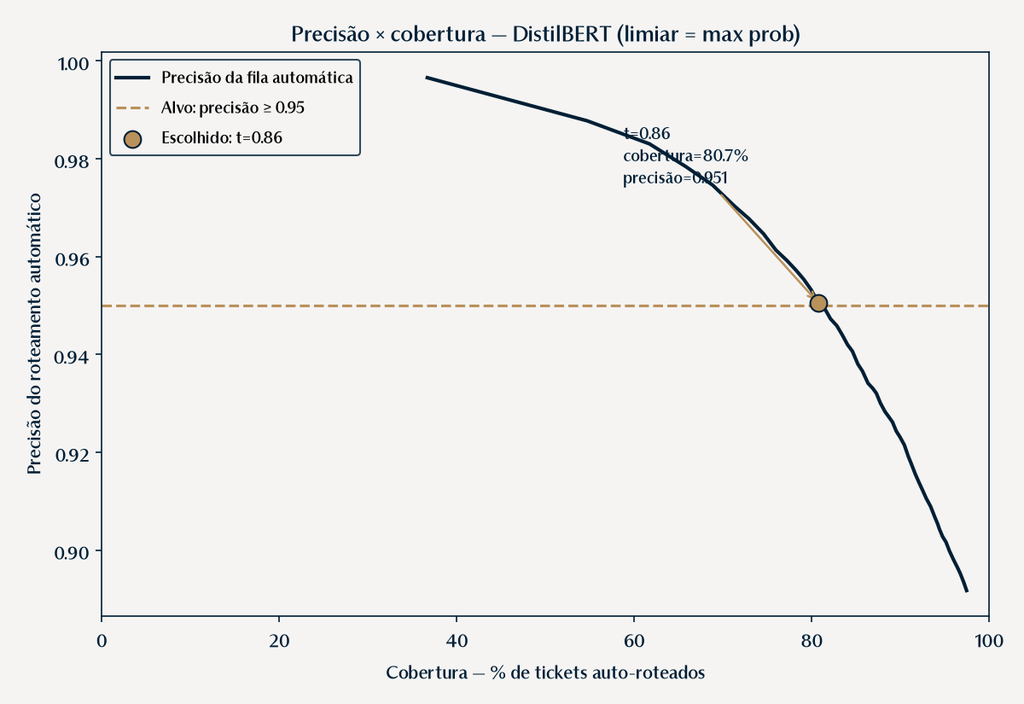

### Impacto real no lote — texto cru de produção

Aplicado ao lote de **8.469 tickets** (`routed_tickets.csv`, texto de produção sem pré-processamento):

| Decisão | Tickets | % |
| --- | --- | --- |
| **AUTO** (confiança ok) | 1.821 | 21,5% |
| HUMANO — baixa confiança | 5.703 | 67,3% |
| HUMANO — classe sensível | 945 | 11,2% |
| HUMANO — total | 6.648 | 78,5% |

### AUTO por tópico no lote

| Tópico | n | % do lote | % AUTO |
| --- | --- | --- | --- |
| Purchase | 4.070 | 48,1% | 25,0% |
| Access | 1.761 | 20,8% | 43,7% |
| Hardware | 1.546 | 18,3% | 1,6% |
| Administrative rights | 945 | 11,2% | 0,0% |
| Miscellaneous | 95 | 1,1% | 8,4% |
| HR Support | 31 | 0,4% | 3,2% |
| Internal Project | 16 | 0,2% | 0,0% |
| Storage | 5 | 0,1% | 0,0% |

Nota de honestidade — distribution shift

No holdout pré-processado, a cobertura AUTO é **80,7%**; no texto cru de produção caiu para **21,5%** — com mediana de confiança de **0,63**, bem abaixo do limiar.

O modelo é menos confiável em texto ruidoso não pré-processado (distribution shift). Antes de escalar a automação: **reprocessar/padronizar o texto de entrada** (o texto de produção traz placeholders e ruído que o treino não viu) e **recalibrar o limiar na operação**, monitorando precisão da fila AUTO semana a semana.

Fontes: `solution/artifacts/router_threshold.json` · `solution/artifacts/routed_tickets.csv` (números derivados nesta página) · `solution/scripts/route_tickets.py` · `solution/scripts/pick_threshold.py`.

4 · O que não automatizamos

## Quatro portas que ficam sempre com uma pessoa

Automação só onde o erro é barato. Onde o erro é caro ou o dado não confere, a decisão é humana por desenho.

### 1 · Administrative rights

Sempre humano. É a classe com pior F1 (0,78) e lida com permissões e acessos de conta — o custo de um erro alto e o recall baixo não justificam automação.

### 2 · Confiança abaixo do limiar

Quando o modelo não tem certeza (< 0,86), o ticket vai para triagem humana. No lote de produção, essa foi a origem de 67,3% dos encaminhamentos.

### 3 · Resposta final ao cliente

A automação só roteia e prioriza. Nenhuma resposta ao cliente sai sem revisão humana — o roteador decide o destino, nunca a mensagem.

### 4 · Nenhuma decisão guiada pelo CSAT atual

A nota se comporta como sorteio (~20% em cada nota, R² = 2%). Nenhum investimento, fila ou prioridade é definido por ela até que a medição seja reconstruída.

5 · Decisões e próximos passos

## O que recuperar agora — e para onde o modelo evolui

### Desperdício recuperável (do relatório)

### 1 · A fila silenciosa — 2.819 tickets

Campanha única de resposta: ~700 h, ~R$ 15 mil, uma vez só. Depois, regra permanente: nenhum ticket sem primeira resposta.

### 2 · Os relógios quebrados

Registrar as datas reais de abertura, resposta e resolução (`created_at`, `first_response_at`, `resolved_at`). Barato, semanas, vale para sempre.

Lembretes proativos destravam os casos parados com a bola na quadra do cliente.

### 4 · As filas erradas

Tickets encaminhados à equipe errada morrem sem resposta. A triagem automática ataca exatamente esta origem — é o que este classificador faz.

### 1 · Padronizar o texto de entrada

Reprocessar o texto cru de produção (placeholders e ruído que o treino não viu). É o caminho mais curto para subir a cobertura AUTO de 21,5% em direção aos 80,7% do holdout.

### 2 · Recalibrar o limiar na operação

Reescolher o ponto na curva precisão × cobertura com dados de produção e monitorar a precisão da fila AUTO semana a semana.

### 3 · DeBERTa / GPU quando disponível

O DistilBERT foi o limite do hardware disponível (treino em 84 min). Com GPU, um modelo maior e mais dados rotulados de produção elevam o teto dos 87,8%.

### 4 · Nunca guiar pelo CSAT atual

Reconstruir a medição: avaliar todos os tickets fechados e registrar os tempos reais junto. Só então a nota volta a ser sinal.